# MLP on the MNIST Digit Data

Biostat 203B

Author

Dr. Hua Zhou @ UCLA

Published

February 27, 2024

Display system information for reproducibility.

**Python**

```python
import IPython
print(IPython.sys_info())
```

```
{'commit_hash': '8b1204b6c',
 'commit_source': 'installation',
 'default_encoding': 'utf-8',
 'ipython_path': '/opt/venv/lib/python3.10/site-packages/IPython',
 'ipython_version': '8.21.0',
 'os_name': 'posix',
 'platform': 'Linux-6.6.12-linuxkit-aarch64-with-glibc2.35',
 'sys_executable': '/opt/venv/bin/python',
 'sys_platform': 'linux',
 'sys_version': '3.10.12 (main, Nov 20 2023, 15:14:05) [GCC 11.4.0]'}
```

**R**

Load some libraries.

**Python**

```python
# Load the pandas library
import pandas as pd
# Load numpy for array manipulation
import numpy as np
# Load seaborn plotting library
import seaborn as sns
import matplotlib.pyplot as plt

# Set font sizes in plots
sns.set(font_scale = 1.2)
# Display all columns
pd.set_option('display.max_columns', None)

# Load Tensorflow and Keras
import tensorflow as tf
from tensorflow import keras
from tensorflow.keras import layers
```

**R**

```r
library(keras)
```

In this example, we train an MLP (multi-layer perceptron) on the [MNIST](https://en.wikipedia.org/wiki/MNIST_database) data set. Achieve testing accuracy 98% after 30 epochs.

- The **MNIST** database (Modified National Institute of Standards and Technology database) is a large database of handwritten digits ($28 \times 28$) that is commonly used for training and testing machine learning algorithms.
- 60,000 training images, 10,000 testing images.

## 1 Prepare data

Acquire data:

**Python**

```python
# Load the data and split it between train and test sets
(x_train, y_train), (x_test, y_test) = keras.datasets.mnist.load_data()
```

```
Downloading data from https://storage.googleapis.com/tensorflow/tf-keras-datasets/mnist.npz
```

```python
# Training set
x_train.shape
```

```
(60000, 28, 28)
```

```python
y_train.shape
```

```
(60000,)
```

```python
# Test set
x_test.shape
```

```
(10000, 28, 28)
```

```python
y_test.shape
```

```
(10000,)
```

Display the first training instance and its label:

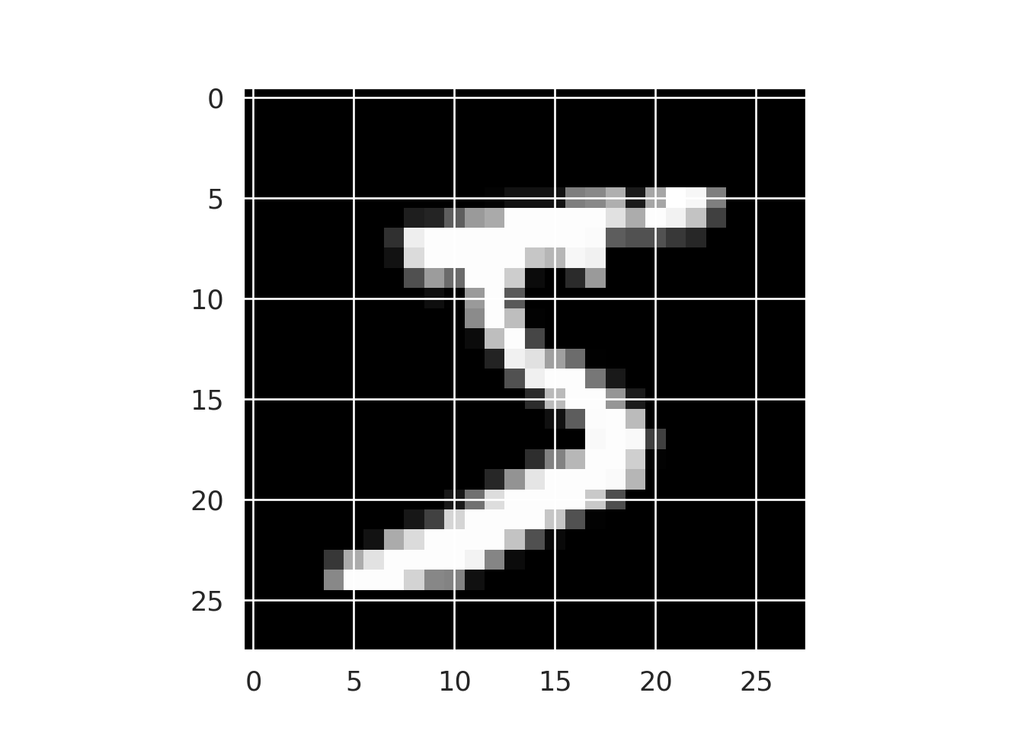

```python
import matplotlib.pyplot as plt

# Feature: digit
plt.figure()
plt.gray()
plt.imshow(x_train[0]);
plt.show()
```

```python
# Label
y_train[0]
```

```
5
```

**R**

```r
mnist <- dataset_mnist()
x_train <- mnist$train$x
y_train <- mnist$train$y
x_test <- mnist$test$x
y_test <- mnist$test$y
```

Training set:

```r
dim(x_train)
```

```
[1] 60000    28    28
```

```r
dim(y_train)
```

```
[1] 60000
```

[figure not shown]

```r
image(
  t(x_train[1, 28:1,]),
  useRaster = TRUE,
  axes = FALSE,
  col = grey(seq(0, 1, length = 256))
  )
```

```r
y_train[1]
```

```
[1] 5
```

Testing set:

```r
dim(x_test)
```

```
[1] 10000    28    28
```

```r
dim(y_test)
```

```
[1] 10000
```

Vectorize $28 \times 28$ images into $784$-vectors and scale entries to [0, 1]:

**Python**

```python
# Reshape
x_train = np.reshape(x_train, [x_train.shape[0], 784])
x_test = np.reshape(x_test, [x_test.shape[0], 784])
# Rescale
x_train = x_train / 255
x_test = x_test / 255
# Train
x_train.shape
```

```
(60000, 784)
```

```python
# Test
x_test.shape
```

```
(10000, 784)
```

**R**

```r
# reshape
x_train <- array_reshape(x_train, c(nrow(x_train), 784))
x_test <- array_reshape(x_test, c(nrow(x_test), 784))
# rescale
x_train <- x_train / 255
x_test <- x_test / 255
dim(x_train)
```

```
[1] 60000   784
```

```r
dim(x_test)
```

```
[1] 10000   784
```

Encode $y$ as binary class matrix:

**Python**

```python
y_train = keras.utils.to_categorical(y_train, 10)
y_test = keras.utils.to_categorical(y_test, 10)
# Train
y_train.shape
```

```
(60000, 10)
```

```python
# Test
y_test.shape
```

```
(10000, 10)
```

```python
# First train instance
y_train[0]
```

```
array([0., 0., 0., 0., 0., 1., 0., 0., 0., 0.], dtype=float32)
```

**R**

```r
y_train <- to_categorical(y_train, 10)
y_test <- to_categorical(y_test, 10)
dim(y_train)
```

```
[1] 60000    10
```

```r
dim(y_test)
```

```
[1] 10000    10
```

```r
head(y_train)
```

```
     [,1] [,2] [,3] [,4] [,5] [,6] [,7] [,8] [,9] [,10]
[1,]    0    0    0    0    0    1    0    0    0     0
[2,]    1    0    0    0    0    0    0    0    0     0
[3,]    0    0    0    0    1    0    0    0    0     0
[4,]    0    1    0    0    0    0    0    0    0     0
[5,]    0    0    0    0    0    0    0    0    0     1
[6,]    0    0    1    0    0    0    0    0    0     0
```

## 2 Define the model

Define a **sequential model** (a linear stack of layers) with 2 fully-connected hidden layers (256 and 128 neurons):

**Python**

```python
model = keras.Sequential(
  [
    keras.Input(shape = (784,)),
    layers.Dense(units = 256, activation = 'relu'),
    layers.Dropout(rate = 0.4),
    layers.Dense(units = 128, activation = 'relu'),
    layers.Dropout(rate = 0.3),
    layers.Dense(units = 10, activation = 'softmax')
]
)

model.summary()
```

```
Model: "sequential"
_________________________________________________________________
 Layer (type)                Output Shape              Param #
=================================================================
 dense (Dense)               (None, 256)               200960

 dropout (Dropout)           (None, 256)               0

 dense_1 (Dense)             (None, 128)               32896

 dropout_1 (Dropout)         (None, 128)               0

 dense_2 (Dense)             (None, 10)                1290

=================================================================
Total params: 235146 (918.54 KB)
Trainable params: 235146 (918.54 KB)
Non-trainable params: 0 (0.00 Byte)
_________________________________________________________________
```

Plot the model:

```python
tf.keras.utils.plot_model(
    model,
    to_file = "model.png",
    show_shapes = True,
    show_dtype = False,
    show_layer_names = True,
    rankdir = "TB",
    expand_nested = False,
    dpi = 96,
    layer_range = None,
    show_layer_activations = False,
)
```

```
You must install pydot (`pip install pydot`) and install graphviz (see instructions at https://graphviz.gitlab.io/download/) for plot_model to work.
```

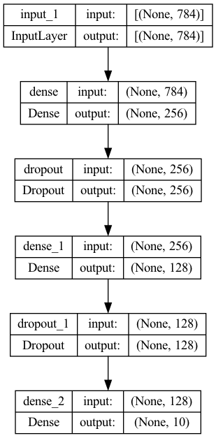

**R**

```r
model <- keras_model_sequential()
model %>%
  layer_dense(units = 256, activation = 'relu', input_shape = c(784)) %>%
  layer_dropout(rate = 0.4) %>%
  layer_dense(units = 128, activation = 'relu') %>%
  layer_dropout(rate = 0.3) %>%
  layer_dense(units = 10, activation = 'softmax')
summary(model)
```

[output not shown]

Compile the model with appropriate loss function, optimizer, and metrics:

**Python**

```python
model.compile(
  loss = "categorical_crossentropy",
  optimizer = "rmsprop",
  metrics = ["accuracy"]
)
```

**R**

```r
model %>% compile(
  loss = 'categorical_crossentropy',
  optimizer = optimizer_rmsprop(),
  metrics = c('accuracy')
)
```

## 3 Training and validation

80%/20% split for the train/validation set.

**Python**

```python
batch_size = 128
epochs = 30

history = model.fit(
  x_train,
  y_train,
  batch_size = batch_size,
  epochs = epochs,
  validation_split = 0.2
)
```

Plot training history:

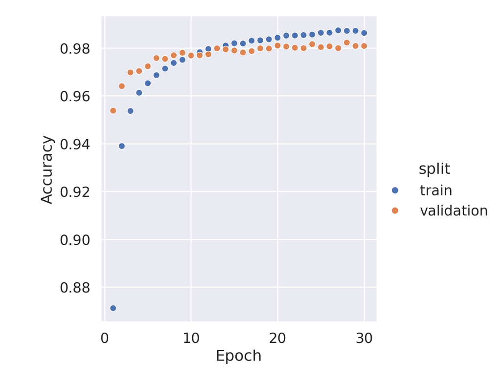

```python
hist = pd.DataFrame(history.history)
hist['epoch'] = np.arange(1, epochs + 1)
hist = hist.melt(
  id_vars = ['epoch'],
  value_vars = ['loss', 'accuracy', 'val_loss', 'val_accuracy'],
  var_name = 'type',
  value_name = 'value'
)
hist['split'] = np.where(['val' in s for s in hist['type']], 'validation', 'train')
hist['metric'] = np.where(['loss' in s for s in hist['type']], 'loss', 'accuracy')

# Accuracy trace plot
plt.figure()
sns.relplot(
  data = hist[hist['metric'] == 'accuracy'],
  kind = 'scatter',
  x = 'epoch',
  y = 'value',
  hue = 'split'
).set(
  xlabel = 'Epoch',
  ylabel = 'Accuracy'
);
plt.show()
```

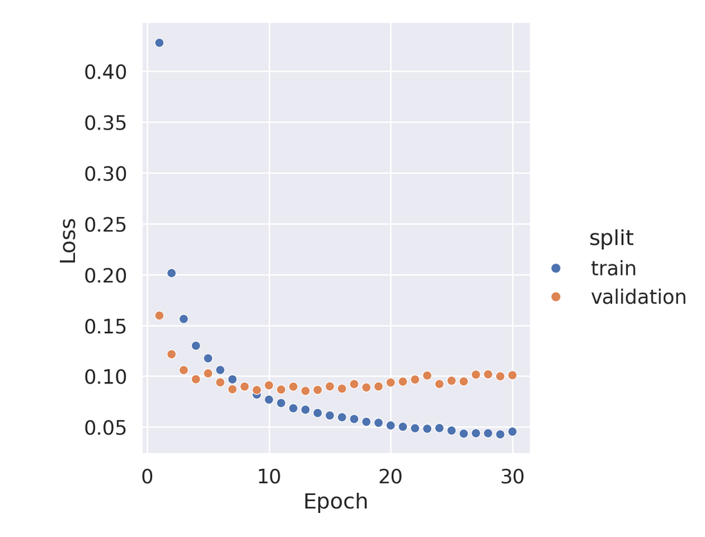

```python
# Loss trace plot
plt.figure()
sns.relplot(
  data = hist[hist['metric'] == 'loss'],
  kind = 'scatter',
  x = 'epoch',
  y = 'value',
  hue = 'split'
).set(
  xlabel = 'Epoch',
  ylabel = 'Loss'
);
plt.show()
```

**R**

```r
system.time({
history <- model %>% fit(
  x_train, y_train,
  epochs = 30, batch_size = 128,
  validation_split = 0.2
)
})
```

```
375/375 - 1s - loss: 0.4300 - accuracy: 0.8703 - val_loss: 0.1623 - val_accuracy: 0.9523 - 1s/epoch - 3ms/step
375/375 - 1s - loss: 0.1997 - accuracy: 0.9415 - val_loss: 0.1185 - val_accuracy: 0.9631 - 1s/epoch - 3ms/step
375/375 - 1s - loss: 0.1571 - accuracy: 0.9537 - val_loss: 0.1077 - val_accuracy: 0.9669 - 1s/epoch - 3ms/step
375/375 - 1s - loss: 0.1322 - accuracy: 0.9611 - val_loss: 0.0948 - val_accuracy: 0.9740 - 1s/epoch - 3ms/step
375/375 - 1s - loss: 0.1148 - accuracy: 0.9654 - val_loss: 0.0967 - val_accuracy: 0.9729 - 1s/epoch - 3ms/step
375/375 - 1s - loss: 0.1022 - accuracy: 0.9699 - val_loss: 0.0856 - val_accuracy: 0.9768 - 1s/epoch - 3ms/step
375/375 - 1s - loss: 0.0951 - accuracy: 0.9714 - val_loss: 0.0881 - val_accuracy: 0.9758 - 1s/epoch - 3ms/step
375/375 - 1s - loss: 0.0868 - accuracy: 0.9733 - val_loss: 0.0908 - val_accuracy: 0.9759 - 1s/epoch - 3ms/step
375/375 - 1s - loss: 0.0808 - accuracy: 0.9757 - val_loss: 0.0839 - val_accuracy: 0.9777 - 1s/epoch - 3ms/step
375/375 - 1s - loss: 0.0788 - accuracy: 0.9757 - val_loss: 0.0798 - val_accuracy: 0.9795 - 1s/epoch - 3ms/step
375/375 - 1s - loss: 0.0735 - accuracy: 0.9781 - val_loss: 0.0868 - val_accuracy: 0.9798 - 1s/epoch - 3ms/step
375/375 - 1s - loss: 0.0739 - accuracy: 0.9780 - val_loss: 0.0864 - val_accuracy: 0.9783 - 1s/epoch - 3ms/step
375/375 - 1s - loss: 0.0662 - accuracy: 0.9807 - val_loss: 0.0850 - val_accuracy: 0.9792 - 1s/epoch - 3ms/step
375/375 - 1s - loss: 0.0632 - accuracy: 0.9812 - val_loss: 0.0844 - val_accuracy: 0.9799 - 1s/epoch - 3ms/step
375/375 - 1s - loss: 0.0622 - accuracy: 0.9812 - val_loss: 0.0825 - val_accuracy: 0.9802 - 1s/epoch - 3ms/step
375/375 - 1s - loss: 0.0581 - accuracy: 0.9826 - val_loss: 0.0855 - val_accuracy: 0.9802 - 1s/epoch - 3ms/step
375/375 - 1s - loss: 0.0596 - accuracy: 0.9824 - val_loss: 0.0877 - val_accuracy: 0.9804 - 1s/epoch - 3ms/step
375/375 - 1s - loss: 0.0553 - accuracy: 0.9834 - val_loss: 0.0882 - val_accuracy: 0.9803 - 1s/epoch - 3ms/step
375/375 - 1s - loss: 0.0544 - accuracy: 0.9838 - val_loss: 0.0828 - val_accuracy: 0.9811 - 1s/epoch - 3ms/step
375/375 - 1s - loss: 0.0544 - accuracy: 0.9844 - val_loss: 0.0873 - val_accuracy: 0.9805 - 1s/epoch - 3ms/step
375/375 - 1s - loss: 0.0527 - accuracy: 0.9847 - val_loss: 0.0885 - val_accuracy: 0.9808 - 1s/epoch - 3ms/step
375/375 - 1s - loss: 0.0497 - accuracy: 0.9848 - val_loss: 0.0897 - val_accuracy: 0.9811 - 1s/epoch - 3ms/step
375/375 - 1s - loss: 0.0481 - accuracy: 0.9859 - val_loss: 0.0921 - val_accuracy: 0.9802 - 1s/epoch - 3ms/step
375/375 - 1s - loss: 0.0479 - accuracy: 0.9847 - val_loss: 0.0971 - val_accuracy: 0.9814 - 1s/epoch - 3ms/step
375/375 - 1s - loss: 0.0483 - accuracy: 0.9858 - val_loss: 0.0979 - val_accuracy: 0.9803 - 1s/epoch - 3ms/step
375/375 - 1s - loss: 0.0476 - accuracy: 0.9861 - val_loss: 0.0880 - val_accuracy: 0.9809 - 1s/epoch - 3ms/step
375/375 - 1s - loss: 0.0444 - accuracy: 0.9874 - val_loss: 0.0941 - val_accuracy: 0.9816 - 1s/epoch - 3ms/step
375/375 - 1s - loss: 0.0434 - accuracy: 0.9874 - val_loss: 0.1077 - val_accuracy: 0.9808 - 1s/epoch - 3ms/step
375/375 - 1s - loss: 0.0405 - accuracy: 0.9879 - val_loss: 0.0921 - val_accuracy: 0.9820 - 1s/epoch - 3ms/step
375/375 - 1s - loss: 0.0439 - accuracy: 0.9874 - val_loss: 0.0929 - val_accuracy: 0.9827 - 1s/epoch - 3ms/step
```

```
   user  system elapsed
 63.770  20.459  34.053
```

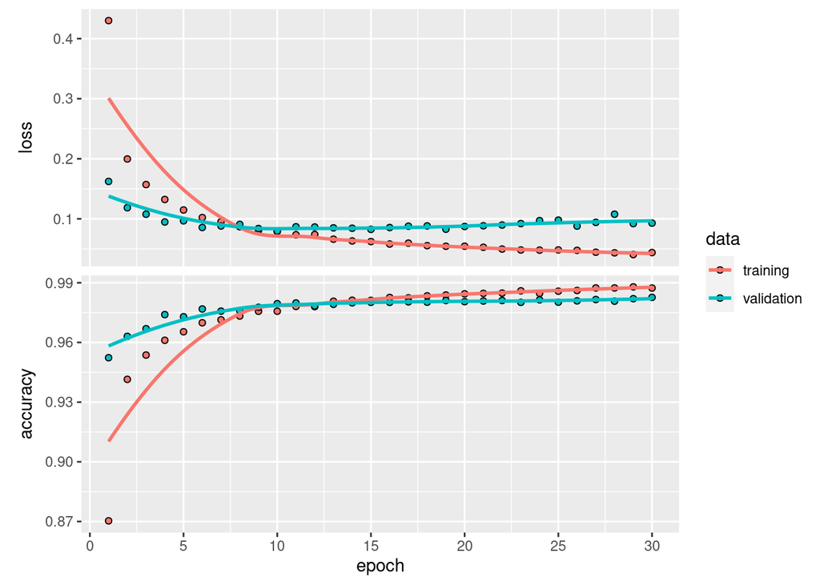

```r
plot(history)
```

## 4 Testing

Evaluate model performance on the test data:

**Python**

```python
score = model.evaluate(x_test, y_test, verbose = 0)
print("Test loss:", score[0])
```

```
Test loss: 0.08709269762039185
```

```python
print("Test accuracy:", score[1])
```

```
Test accuracy: 0.9825000166893005
```

**R**

```r
model %>% evaluate(x_test, y_test)
```

```
313/313 - 0s - loss: 0.0835 - accuracy: 0.9836 - 185ms/epoch - 591us/step
```

```
      loss   accuracy
0.08349238 0.98360002
```

Generate predictions on new data:

```r
model %>% predict(x_test) %>% k_argmax()
```

```
313/313 - 0s - 208ms/epoch - 663us/step
```

```
tf.Tensor([7 2 1 ... 4 5 6], shape=(10000), dtype=int64)
```

## 5 Exercise

Suppose we want to fit a multinomial-logit model and use it as a baseline method to neural networks. How to do that? Of course we can use `mlogit` or other packages. Instead we can fit the same model using keras, since multinomial-logit is just an MLP with (1) one input layer with linear activation and (2) one output layer with softmax link function.

**Python**

**R**

```r
# set up model
library(keras)
mlogit <- keras_model_sequential()
mlogit %>%
#  layer_dense(units = 256, activation = 'linear', input_shape = c(784)) %>%
#  layer_dropout(rate = 0.4) %>%
  layer_dense(units = 10, activation = 'softmax', input_shape = c(784))
summary(mlogit)
```

```
Model: "sequential_2"
________________________________________________________________________________
 Layer (type)                       Output Shape                    Param #
================================================================================
 dense_6 (Dense)                    (None, 10)                      7850
================================================================================
Total params: 7850 (30.66 KB)
Trainable params: 7850 (30.66 KB)
Non-trainable params: 0 (0.00 Byte)
________________________________________________________________________________
```

```r
# compile model
mlogit %>% compile(
  loss = 'categorical_crossentropy',
  optimizer = optimizer_rmsprop(),
  metrics = c('accuracy')
)
mlogit
```

```
Model: "sequential_2"
________________________________________________________________________________
 Layer (type)                       Output Shape                    Param #
================================================================================
 dense_6 (Dense)                    (None, 10)                      7850
================================================================================
Total params: 7850 (30.66 KB)
Trainable params: 7850 (30.66 KB)
Non-trainable params: 0 (0.00 Byte)
________________________________________________________________________________
```

```r
# fit model
mlogit_history <- mlogit %>%
  fit(
    x_train,
    y_train,
    epochs = 20,
    batch_size = 128,
    validation_split = 0.2
  )
```

```
375/375 - 0s - loss: 0.6682 - accuracy: 0.8367 - val_loss: 0.3600 - val_accuracy: 0.9047 - 468ms/epoch - 1ms/step
375/375 - 0s - loss: 0.3530 - accuracy: 0.9034 - val_loss: 0.3100 - val_accuracy: 0.9141 - 314ms/epoch - 838us/step
375/375 - 0s - loss: 0.3181 - accuracy: 0.9112 - val_loss: 0.2956 - val_accuracy: 0.9172 - 314ms/epoch - 838us/step
375/375 - 0s - loss: 0.3019 - accuracy: 0.9161 - val_loss: 0.2864 - val_accuracy: 0.9205 - 305ms/epoch - 813us/step
375/375 - 0s - loss: 0.2922 - accuracy: 0.9178 - val_loss: 0.2783 - val_accuracy: 0.9232 - 324ms/epoch - 864us/step
375/375 - 0s - loss: 0.2858 - accuracy: 0.9202 - val_loss: 0.2758 - val_accuracy: 0.9235 - 305ms/epoch - 814us/step
375/375 - 0s - loss: 0.2807 - accuracy: 0.9213 - val_loss: 0.2715 - val_accuracy: 0.9251 - 306ms/epoch - 816us/step
375/375 - 0s - loss: 0.2769 - accuracy: 0.9226 - val_loss: 0.2707 - val_accuracy: 0.9268 - 317ms/epoch - 846us/step
375/375 - 0s - loss: 0.2738 - accuracy: 0.9244 - val_loss: 0.2677 - val_accuracy: 0.9261 - 306ms/epoch - 817us/step
375/375 - 0s - loss: 0.2710 - accuracy: 0.9251 - val_loss: 0.2666 - val_accuracy: 0.9279 - 303ms/epoch - 807us/step
375/375 - 0s - loss: 0.2687 - accuracy: 0.9255 - val_loss: 0.2658 - val_accuracy: 0.9273 - 373ms/epoch - 996us/step
375/375 - 0s - loss: 0.2666 - accuracy: 0.9262 - val_loss: 0.2668 - val_accuracy: 0.9277 - 322ms/epoch - 859us/step
375/375 - 0s - loss: 0.2648 - accuracy: 0.9272 - val_loss: 0.2649 - val_accuracy: 0.9282 - 308ms/epoch - 820us/step
375/375 - 0s - loss: 0.2634 - accuracy: 0.9267 - val_loss: 0.2633 - val_accuracy: 0.9302 - 308ms/epoch - 822us/step
375/375 - 0s - loss: 0.2621 - accuracy: 0.9273 - val_loss: 0.2638 - val_accuracy: 0.9300 - 325ms/epoch - 868us/step
375/375 - 0s - loss: 0.2606 - accuracy: 0.9280 - val_loss: 0.2637 - val_accuracy: 0.9286 - 320ms/epoch - 853us/step
375/375 - 0s - loss: 0.2597 - accuracy: 0.9285 - val_loss: 0.2628 - val_accuracy: 0.9298 - 308ms/epoch - 821us/step
375/375 - 0s - loss: 0.2582 - accuracy: 0.9292 - val_loss: 0.2631 - val_accuracy: 0.9308 - 304ms/epoch - 811us/step
375/375 - 0s - loss: 0.2574 - accuracy: 0.9293 - val_loss: 0.2622 - val_accuracy: 0.9301 - 303ms/epoch - 807us/step
375/375 - 0s - loss: 0.2562 - accuracy: 0.9298 - val_loss: 0.2620 - val_accuracy: 0.9298 - 322ms/epoch - 859us/step
```

```r
# Evaluate model performance on the test data:
mlogit %>% evaluate(x_test, y_test)
```

```
313/313 - 0s - loss: 0.2666 - accuracy: 0.9272 - 126ms/epoch - 404us/step
```

```
     loss  accuracy
0.2665513 0.9272000
```

Generate predictions on new data:

```r
mlogit %>% predict(x_test) %>% k_argmax()
```

```
313/313 - 0s - 122ms/epoch - 388us/step
```

```
tf.Tensor([7 2 1 ... 4 5 6], shape=(10000), dtype=int64)
```

Experiment: Change the `linear` activation to `relu` in the multinomial-logit model and see the change in classification accuracy.